# Violencia hacia la mujer en relación al desarrollo económico

## Introducción

La violencia hacia la mujer es un tema que se ha estudiado ampliamente sobretodo en epocas actuales, lo que ha permitido concientizar y visibilizar la oprecion a la cual se somete diariamente a mujeres y niñas, la cultura, religion y tradicion son unos de los factores que retrazan el desarrollo pleno de rgan parte de la pblacion por su condicion de genero.

En el presente, lo que se busca es notar como el desarrollo económico se relaciona con la forma en la que se restringe la integridad fisica de las mujeres, tomando en cuenta la proteccion que la ley les brinda y la actitud de la poblacion en general ante los actos de violencia hacia ellas.

Para esto se utiliza informacion de "The Gender, Institutions and Development Database (GID-DB)" del año 2019 sobre violencia hacia la mujer, mas especificamente en lo correspondiente a integridad fisica restringida, y se contrasta con la informacion del World Economic Outlook Database del Fondo Monetario Internacional.

## Resultados

### Mujeres que han sufrido violencia fisica o sexual por parte de su pareja.

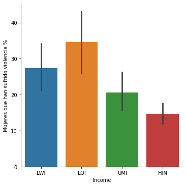

Esta violencia esta internalizada que incluso algunas mujeres sienten que esta está justificada, y que un hombre tiene derecho a violentar a su pareja en casos de que queme la comida, discuta con la pareja, salga de la casa sin avisar o se rehuse a mantener relaciones sexuales. En Africa el 41.66% de las mujeres consideran justificada la violencia, siendo la region que mas acepta este tipo de comportamientos, en contraste con Europa con un 7.61% de mujeres con este tipo de consideraciónes.

### Procetaje de mujeres que considera justificada la violencia hacia ellas

| Region | % |
| --- | --- |
| AFR | 41.668750 |
| AME | 10.775000 |
| ASI | 27.369048 |
| EUR | 7.610526 |

Lo anterior da una persepcion hace notorio el contraste en violencia de genero en cuanto a regiones y hace que surga la duda de como la condicion económica de estas puede estar relacionada.

Parte de lo que define el papel del gobierno en el desarrollo socio-economico es el gasto ejercido, ya que es el indicador que mas refleja las acciones no solo por el avance de la economía sino de la sociedad. Como es posible observar a continuacion, existe una relacion negativa ente el gasto del gobierno como porcentaje del PIB y el porcentaje de mujeres que considera justificado que un hombre la violente, esto quiere decir que mientras mas mas gasto publico realiza el gobierno menos mujeres son propensas a apoyar y justificar la violencia domestica que se ajerce sobre ellas.

### Mujeres que consideran justificada la violencia en relacion al gasto publico

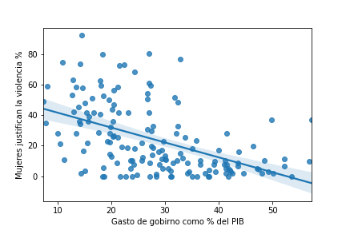

El papel de la autoridad juega un rol importante en la perpetuacion de las ideologias de genero, por lo cual es de suma importancia contar con el soporte de esta para cambiar las ideas que oprimen a las mujeres, la diponibilidad de las autoridades a protejera las niñas y mujeres legalmente tiene que hacerse notar.

Al analisar si las leyes de los paises protegen a las mujeres de violencia domestica, violación y acoso sexual, resalta el hecho de que en ningun pais se considera que la mujer esta totalmente protegida por la ley, sin embargo, los paises que presentaron un PIB per capita mas alto fueron los que mas proteccion por parte de la ley presentaron. Aqui cabe señalar que incluso los paises con PIBpc alto, no quedaron excentos de considerarse con nada de proteccion contra este tipo de crimenes.

### Protección de las leyes a mujeres que sufren violencia fisica o sexual

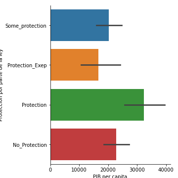

Por otra parte, donde si es posible notar la influencia del desarrollo económico en la proteccion de la mujer es en cuanto a la salud reproductiva y planeación familiar, ya que es facil identificar que mientras mayor es el PIB per capita del pais mas proteccion tienen las muejeres en tomar desisicones sobre su propio cuerpo y salud reproductiva sin la necesidad de justificar su desicion.

### Proteccion de las desiciones reproductivas de la mujer, segun el PIB per capita del pais

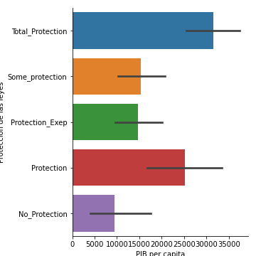

Esto ultimo es muy importante ya que es una situacion usual el que la mujer no este en total control de su salud reproductiva, ya sea por cuestiones legales, como en el caso de la legalizacion del aborto, como en la falta de educación sexual o represion por parte de la pareja.

En todas las regiones, con excepción de Europa, las mujeres delos paises con bajos ingresos son las que menos control tiene sobre su cuerpo, ya que incluso cuando no tiene deseos de tener hijos no tienen acceso o no se les permite obtener metodos anticonceptivos.

### Mujeres casadas sin deseos de ser madres que no cuentan con metodos anticonceptivos

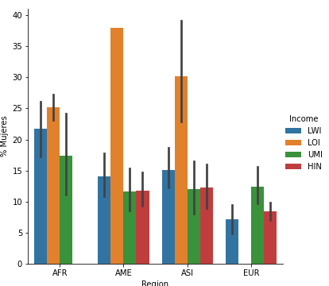

## Conclusión

La violencia hacia la mujer es causada por varias razones, no es posible adjudicar toda la resposabilidad a un solo factor, sin embargo, si es posible identificar variables que afectan la libertas e integridad fisica de la mujer. El desarrollo económico es un factor que se desarrollo en paralelo con la sociedad, por lo cual es facil identificar que existe una relación entre el bienestar económico y social.

Si bien, la violencia de genero no es exclusiva de paises de bajos ingresos, si se muestra una relacion de mayor insidencias en mujeres violentadas en estos paises en comparación con los que cuentan con ingresos mas altos.

Esta violencia esta tan arraigada, sobre todo en la región de Africa, que gran parte de las mujeres sienten que esta bien que se le violente justificando al agresor, esta ideología es muy dañina para la sociedad ya que perpetúa un comportamiento retrogrado, lo que puede propisiar la falta de desarollo socio-economio, ya que si gran parte de la población es considerado ciudadano de segunda clase la sociedad en su conjunto no avanza de forma optima.

El desarrollo económico no es la solucion a la violencia sistematica hacia la mujer, sin embargo, si es un factor a tomar en cuenta para lograr un desembolvimiento pleno de la mujer en la sociedad.